# Utilisation des fonctions aux données obtenue avec l’IKS

```r
source("../R/function.R")
```

# Exemple de correction de données obtenues avec l’IKS

En partant d’un jeu de données fictif sur la mesure du pH en continu, nous obtenons le graphique suivant :

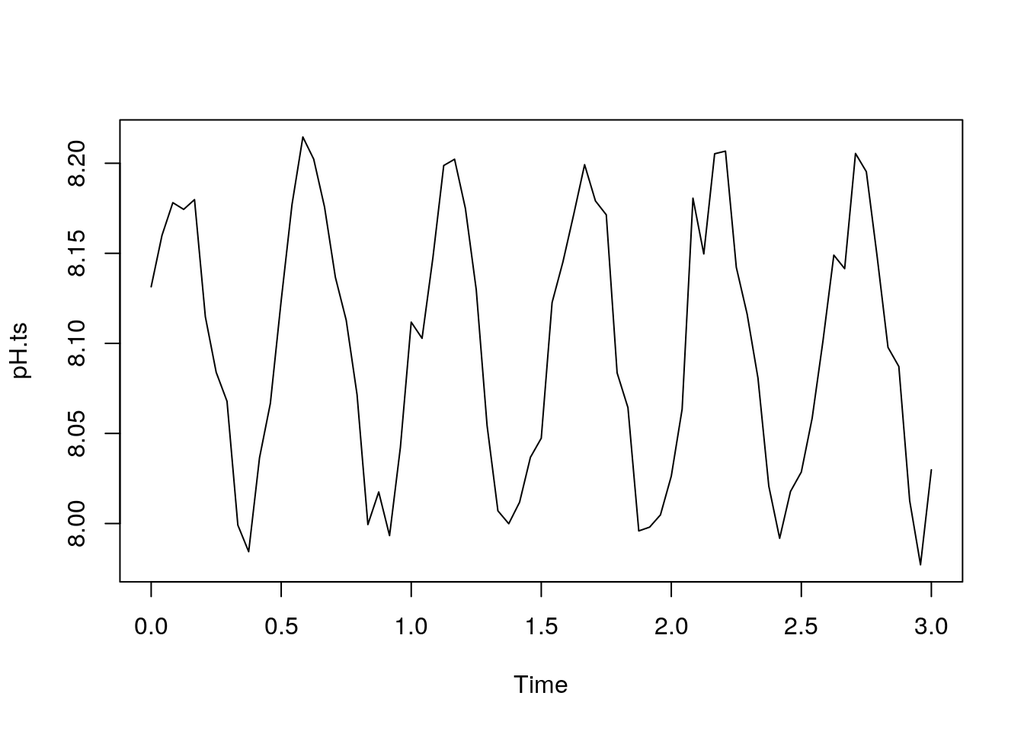

```r
# Exemple
# Correction du pH mesuré en continu à partir de mesures quotidiennes
pH <- rep(8.1, 24 * 3 + 1) + sin((1:(24 * 3 + 1)) / 2)/10 +
 rnorm(24 * 3 + 1, mean = 0, sd = 0.02)
# Transformation en série temporelle, en tenant compte du temps écoulé
# Mesures toutes les heures:
dates <- Sys.time() + 1:(24 * 3 + 1) * 3600
# Unité temporelle = 1 jour
pH.ts <- ts(pH, start = 0, frequency = 24)
plot(pH.ts)
```

Afin d’avoir une plus haute précision, des mesures sont prises avec un instruments de plus haute précision.

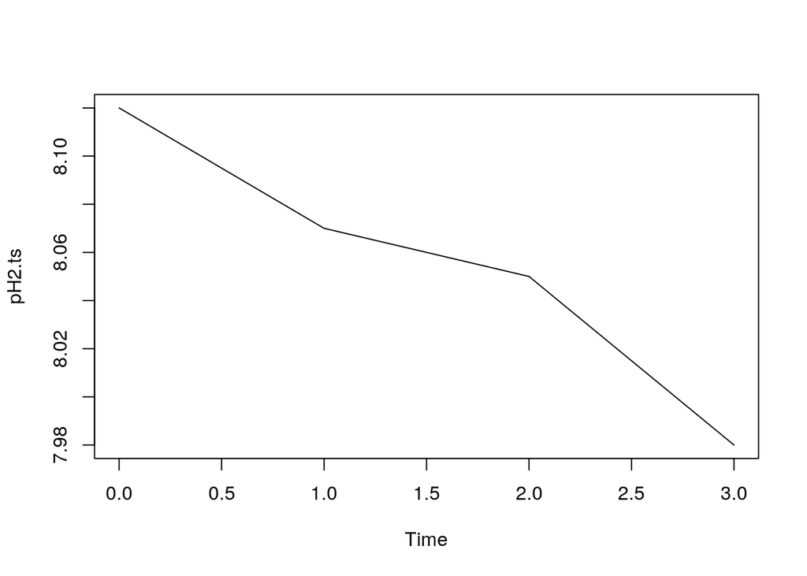

```r
## Etalonnage quotidien
pH2 <- c(8.12, 8.07, 8.05, 7.98)
dates2 <- Sys.time() + 0:3 * (24 * 3600)
pH2.ts <- ts(pH2, start = 0, frequency = 1)
plot(pH2.ts)
```

Il est donc possible de superposer les données de l’iks avec les données avec les données obtenues avec l’instruments plus précis

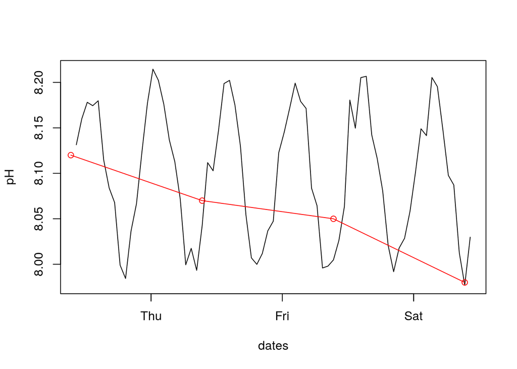

```r
plot(dates, pH, type = "l")
lines(dates2, pH2, col = "red")
lines(dates2, pH2, col = "red", type = "p")
```

La fonction correct monitoring va permettre d’appliquer la correction des données iks.

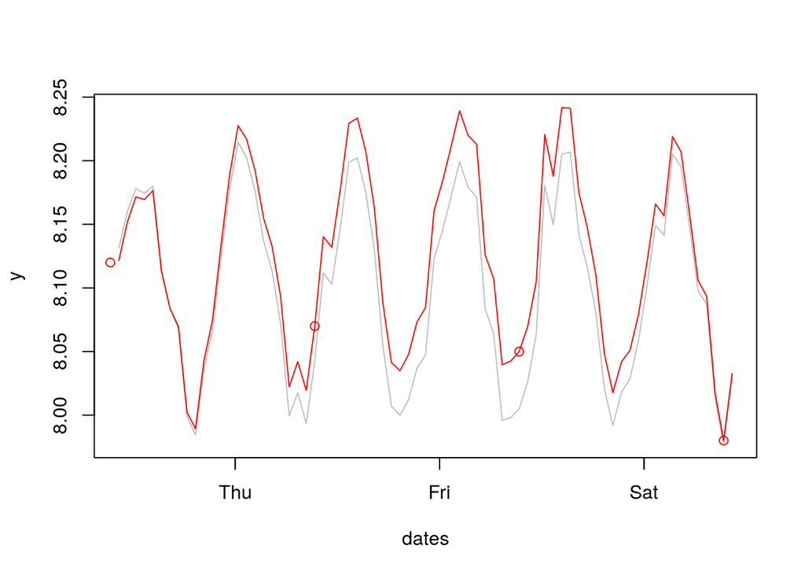

```r
pHcorr <- correct_monitoring(dates, pH, dates2, pH2, extrapolate = TRUE)
plot(pHcorr)
```

La fonction correct_monitoring comprend commes arguments :

- dates : Temps de l’IKS mesuré avec l’ordinateur
- values : valeur mesuréepar l’IKS (oxygène, pH,…)
- calib.dates: Temps lors de prise des paramètres avec un instruement de plus haute précision.
- calib.values: Valeur mesurée avec l’instruments de précision.
- extrapolate : cet argument est à FALSE par défaut. Il permet de spécifier si l’on souhaite uniquement être dnas les bornes mesurées avec l’instruments de précision.

# Mesure de taux de respiration via les données fournies pour l’IKS

La fonction respirometry() permet de calculer la respiration d’individus avec les arguments suivants :

```r
# Example of use: read data for two consecutive days
datarespi <- rbind(readRDS("../data/IKS.Data.2017-05-01.rds"),
                   readRDS("../data/IKS.Data.2017-05-02.rds"))

# Choice of the series, and indication of mass and ref.respi
series <- "O2mgL_4"
mass <- 74 #g
ref.respi <- -0.01
title <- "Etoile de mer"
n1 <- 1
```

Les arguments de la fonction respirometry sont les suivants :

- data : Jeu de données
- series : Nom de la séries analysées
- pos : Provient de la série de nombre caculé via la fonction identify. Pour spécifier le début de chaque période.
- n :
- mass : Masse de la bouture
- vol.respi : volume du respiromètre
- ref.respi : Correction faites sur la respiromètre ?
- main : Titre du graphique ??

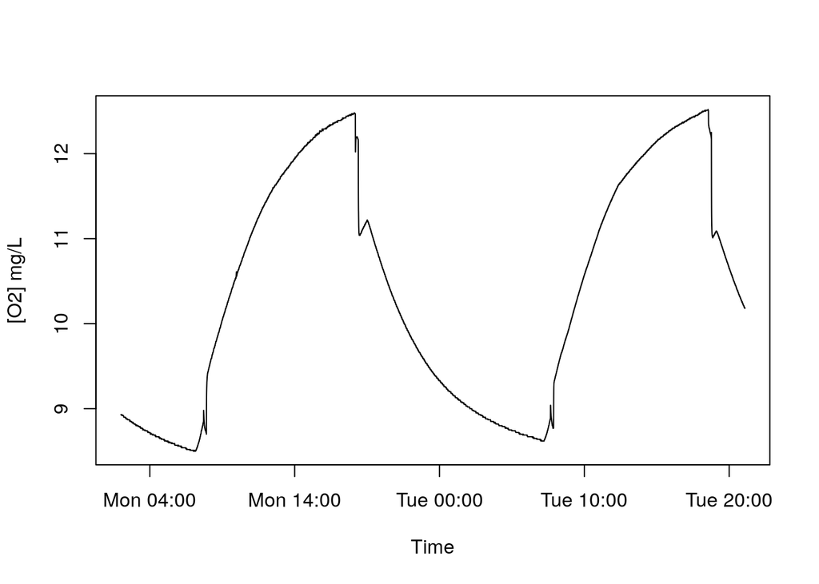

```r
plot(datarespi$Time, datarespi[[series]], type = "l", xlab = "Time",  ylab = "[O2] mg/L")
```

Ensuite, vous devez venir sélectionner les zones d’intérêt avec la fonction identify() mais atteniton que vous devez garder les positions

```r
# La fonction pos s'exécute dans un script R de préférence
#plot(datarespi$Time, datarespi[[series]], type = "l", xlab = "Time",  ylab = "[O2] mg/L")
#pos <- identify(datarespi$Time, datarespi[[series]])

# Sauvegarde du vecteur
#pos
#position <- tibble::data_frame(Posi = pos, Time = datarespi$Time[pos])
#data.io::write(position, file = "data/position.rds", type = "rds")
position <- data.io::read("../data/position.rds", type ="rds")
```

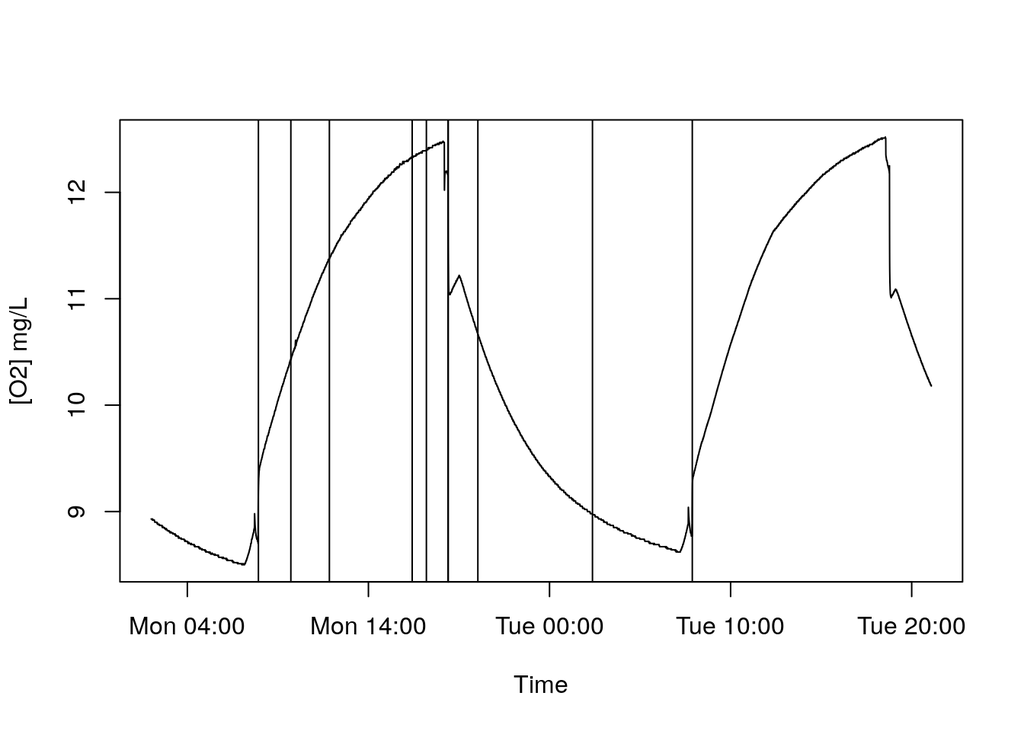

```r
plot(datarespi$Time, datarespi[[series]], type = "l", xlab = "Time",  ylab = "[O2] mg/L")
abline(v = position$Time)
```

```r
#res <- respirometry(datarespi, series, position$Posi, n = n1, mass = mass, ref.respi = ref.respi, main = title)
#res <- rbind(res, respirometry(datarespi, series, position$Posi, n = n1+1, mass = mass, ref.respi = ref.respi, main = title))
```

On produit un jeu de données ligne par ligne avec le calcul de la respiration. Il faut également sauver ce fichier

```r
#data.io::write(res, file = "data/respirometry.rds", type = "rds")
(res <- data.io::read("../data/respirometry.rds", type = "rds"))
```

```
## # A tibble: 2 x 6
##   rownames time0               time1                 respi ref.respi ref
##   <chr>    <dttm>              <dttm>                <dbl>     <dbl> <fct>
## 1 Time     2017-05-01 07:55:27 2017-05-01 09:42:59 0.0105      -0.01 Etoil…
## 2 Time1    2017-05-01 11:50:37 2017-05-01 16:24:57 0.00376     -0.01 Etoil…
```